# 2D-Discrete Dynamical Systems (Assignment Sheet 3)

Introduction To Chaos Applied To Systems, Processes And Products (ETSIDI, UPM)

Alfonso Allen-Perkins, Juan Carlos Bueno and Eduardo Faleiro

2025-02-20

## Introduction: Plotting 2D-orbits in R

Before solving the exercises, let’s go through an example of how to plot the orbits of a 2D map using R. We will use the Gingerbreadman map, which is a simple example of a chaotic dynamical system that generates intricate, non-repeating patterns from a piecewise linear transformation.

The Gingerbreadman map is given by the equations:

$$x_{n+1} = 1 - y_n + |x_n|$$
$$y_{n+1} = x_n$$

To visualize orbits of this system in R, follow these steps:

1. **Load ggplot2 for visualization:**

```r
library(ggplot2)
```

2. **Define the function to generate the Gingerbreadman map:**

```r
gingerbreadman_map <- function(x0, y0, n) {
x <- numeric(n)
y <- numeric(n)
x[1] <- x0
y[1] <- y0

for (i in 2:n) {
  x[i] <- 1 - y[i-1] + abs(x[i-1])
  y[i] <- x[i-1]
}

data.frame(x, y)
}
```

2. **Generate orbit with initial conditions:**

```r
data_gbm <- gingerbreadman_map(1.1, 6.1, 10000)
```

3. **Plot the orbit using `ggplot2`:**

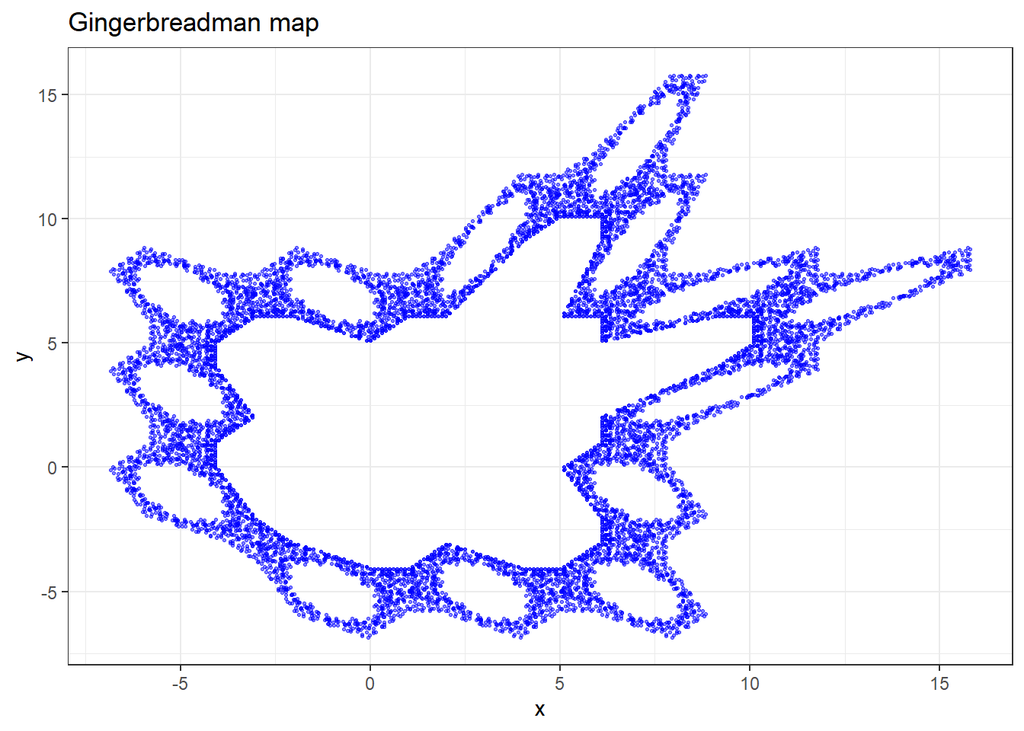

```r
ggplot(data_gbm, aes(x = x, y = y)) +
 geom_point(color = 'blue', alpha = 0.5, size = .5) +
 labs(title = "Gingerbreadman map", x = "x", y = "y") +
 theme_bw()
```

You can modify the parameters to observe different behaviors of the above map using `ggplot2`.

## Exercise 1: The Lotka-Volterra discrete map

The Lotka-Volterra discrete map models predator-prey interactions in a discrete-time framework, capturing oscillatory population dynamics and potential chaotic behavior. The long-term behavior of the system can converge to fixed points, periodic cycles, or chaotic attractors, depending on the parameter values.

The discrete 2D Lotka-Volterra map is given by:

$$x_n = \frac{\alpha x_{n-1} - \beta x_{n-1} y_{n-1}}{1 + \gamma x_{n-1}}$$
$$y_n = \frac{\delta y_{n-1} - \epsilon x_{n-1} y_{n-1}}{1 + \eta y_{n-1}}$$

where:

- Case 1: $\alpha = 170, \beta = 11, \gamma = 2.7, \delta = 50, \epsilon = 1.7, \eta = 7, x_1 = 7, y_1 = 5$
- Case 2: $\alpha = 1.001, \beta = 0.03, \gamma = 0.6, \delta = 1.002, \epsilon = 1.7, \eta = 0.9, x_1 = 0.0002, y_1 = 0.0006$

Plot the solution (orbit) of the discrete dynamical system for both cases.

## Exercise 2: The Henon map (1976)

The Henon map is a simplified model of chaotic dynamics in two dimensions, originally derived from a model of stellar motion in galaxies. It exhibits a well-known strange attractor, which demonstrates sensitive dependence on initial conditions, a key feature of chaotic systems.

The Henon map is given by the equations:

$$x_{n+1} = y_n + 1 - a x_n^2$$
$$y_{n+1} = b x_n$$

where $a$ and $b$ are adjustable parameters. Set $a = 1.4$ and $b = 0.3$, then plot $x_n$ vs $y_n$.

## Exercise 3: The standard map (Chirikov 1971)

The Standard Map, also known as the Chirikov-Taylor Map, is a key model in Hamiltonian chaos, describing the transition from regular to chaotic motion in conservative dynamical systems. Depending on the parameter $b$, the system can display stable islands, chaotic seas, or a mixture of both.

The Standard map is defined as follows:

$$x_{n+1} = y_{n+1} + x_n$$
$$y_{n+1} = y_n + b \sin(x_n)$$

- 1. Plot various orbits for $b = 0$.
- 2. Plot the phase portrait for $b = 0.5$.
- 3. Show the phase portrait for $b = 1$ and $b = 2$.

## Exercise 4: The Lozi map (1978)

The Lozi map is a piecewise linear version of the Henon map that retains its chaotic properties while being computationally simpler to analyze. It generates a strange attractor with a fractal structure, making it an important example in the study of deterministic chaos.

The Lozi map is defined by:

$$x_{n+1} = y_n + 1 - a |x_n|$$
$$y_{n+1} = b x_n$$

where $-1 < b < 1$. Plot orbits when $a = 1.7$ and $b = 0.5$.